# Greenhouse Gases - R Notebook

Jenna Atma

2021-08-26

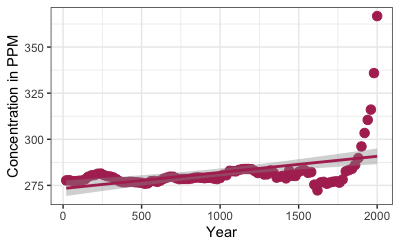

```
Analysis of Variance Table

Response: concentration
           Df   Sum Sq Mean Sq F value  Pr(>F)
year        1   265918  265918  5.6533 0.01805 *
Residuals 298 14017258   47038
---
Signif. codes:  0 ‘***’ 0.001 ‘**’ 0.01 ‘*’ 0.05 ‘.’ 0.1 ‘ ’ 1

Call:
lm(formula = concentration ~ year, data = greenhouse_gases)

Residuals:
   Min     1Q Median     3Q    Max
-189.4 -152.4 -119.2  240.7 1236.2

Coefficients:
             Estimate Std. Error t value Pr(>|t|)
(Intercept) 364.07412   25.23238  14.429   <2e-16 ***
year          0.05157    0.02169   2.378   0.0181 *
---
Signif. codes:  0 ‘***’ 0.001 ‘**’ 0.01 ‘*’ 0.05 ‘.’ 0.1 ‘ ’ 1

Residual standard error: 216.9 on 298 degrees of freedom
Multiple R-squared:  0.01862,   Adjusted R-squared:  0.01532
F-statistic: 5.653 on 1 and 298 DF,  p-value: 0.01805
```

Figure displaying the mean concentrations (in PPM) between the three main greenhouse gas types (carbon dioxide, methane, and nitrous oxide) over the past 2,000 years. We have 300 total records of greenhouse gas concentration measurements, with the average concentration of 416.1596667 PPM. Gases range from 260 to 1703.4 PPM.

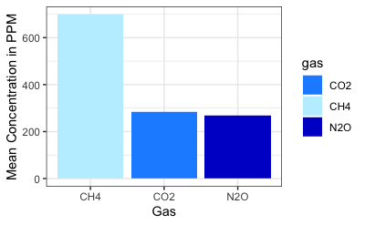

This table shows the first 10 entries from the greenhouse gases dataset.

Table 1. A knitr kable displaying the first 200 years recorded of CO2 cencentration in the data set.

| year | gas | concentration |
| --- | --- | --- |
| 20 | CO2 | 277.7 |
| 40 | CO2 | 277.8 |
| 60 | CO2 | 277.3 |
| 80 | CO2 | 277.3 |
| 100 | CO2 | 277.5 |
| 120 | CO2 | 277.6 |
| 140 | CO2 | 278.3 |
| 160 | CO2 | 279.7 |
| 180 | CO2 | 280.4 |
| 200 | CO2 | 280.6 |

Here’s another table that summarizes the concentration of greenhouse gases data.

Table 2. A summary kable displaying number, mean, and standard deviation for each of three types of greenhouse gasses.

| gas | n | mean | sd |
| --- | --- | --- | --- |
| CH4 | 100 | 697.883 | 154.02756 |
| CO2 | 100 | 282.124 | 11.87637 |
| N2O | 100 | 268.472 | 7.76121 |

For a change of pace, here’s a map of one of my study sites for my thesis project, which is located in the Cheatham Wildlife Management Area in Cheatham County, TN.

[interactive chart not shown]

*And for fun….*

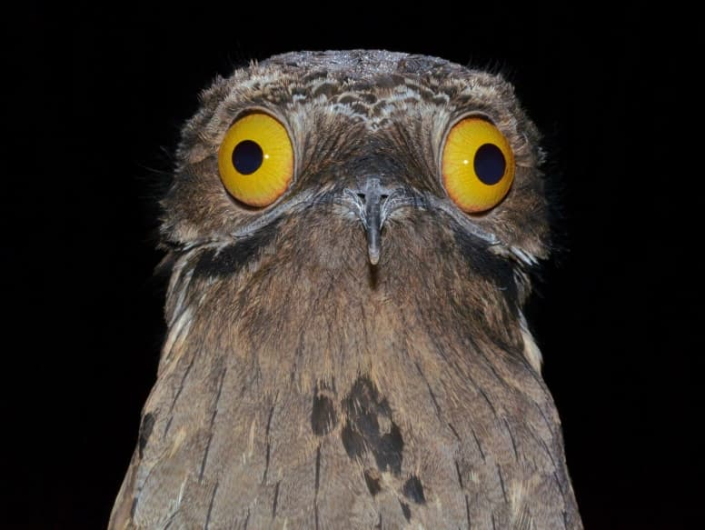

Figure 1. A majestic portrait of a Potoo (*family Nyctibiidae*)

*Some more Potoo love:*

[video not shown]